# R Notebook

An Analytical Detective

## Problem - Loading the Data

```r
mvt= read.csv("~/Downloads/mvtWeek1.csv")
str(mvt)
```

```
'data.frame':   191641 obs. of  11 variables:
 $ ID                 : int  8951354 8951141 8952745 8952223 8951608 8950793 8950760 8951611 8951802 8950706 ...
 $ Date               : Factor w/ 131680 levels "10/10/01 0:00",..: 37302 37300 37300 37300 37299 37297 37296 37295 37291 37290 ...
 $ LocationDescription: Factor w/ 78 levels "ABANDONED BUILDING",..: 72 72 62 72 72 72 72 72 72 72 ...
 $ Arrest             : logi  FALSE FALSE FALSE FALSE FALSE TRUE ...
 $ Domestic           : logi  FALSE FALSE FALSE FALSE FALSE FALSE ...
 $ Beat               : int  623 1213 1622 724 211 2521 423 231 1021 1215 ...
 $ District           : int  6 12 16 7 2 25 4 2 10 12 ...
 $ CommunityArea      : int  69 24 11 67 35 19 48 40 29 24 ...
 $ Year               : int  2012 2012 2012 2012 2012 2012 2012 2012 2012 2012 ...
 $ Latitude           : num  41.8 41.9 42 41.8 41.8 ...
 $ Longitude          : num  -87.6 -87.7 -87.8 -87.7 -87.6 ...
```

So there are 191641 observations and 11 variables

```r
max(mvt$ID)
```

```
[1] 9181151
```

Max Value of ‘ID’ : 9181151

```r
min(mvt$Beat)
```

```
[1] 111
```

Min Value of ‘Beat’ : 111

```r
summary(mvt$Arrest)
```

```
   Mode   FALSE    TRUE
logical  176105   15536
```

Count of ‘Arrest’ TRUE values : 15536

```r
summary(mvt$LocationDescription=='ALLEY')
```

```
   Mode   FALSE    TRUE
logical  189333    2308
```

Count of Observations with ‘ALLEY’ in LocationDescription: 2308

## Problem - Understanding Dates in R

```r
mvt$Date[1]
```

```
[1] 12/31/12 23:15
131680 Levels: 10/10/01 0:00 10/10/01 0:01 10/10/01 0:30 10/10/01 0:40 ... 9/9/12 9:50
```

Date Format : Month/Day/Year Hour:Minute

Convert the Date characters into Date object

```r
DateConvert=as.Date(strptime(mvt$Date,"%m/%d/%y %H:%M"))
summary(DateConvert)
```

```
        Min.      1st Qu.       Median         Mean      3rd Qu.         Max.
"2001-01-01" "2003-07-10" "2006-05-21" "2006-08-23" "2009-10-24" "2012-12-31"
```

Median Value: May 2006

Extract Months and Weekdays and Add to dataset

```r
mvt$Month=months(DateConvert)
mvt$Weekday=weekdays(DateConvert)
mvt$Date=DateConvert
table(mvt$Month)
```

```
    April    August  December  February   January      July      June     March
    15280     16572     16426     13511     16047     16801     16002     15758
      May  November   October September
    16035     16063     17086     16060
```

Fewest motor vehicle thefts in : February

```r
table(mvt$Weekday)
```

```
   Friday    Monday  Saturday    Sunday  Thursday   Tuesday Wednesday
    29284     27397     27118     26316     27319     26791     27416
```

Most motor vehicle thefts on : Friday

```r
table(mvt$Arrest,mvt$Month)
```

```
        April August December February January  July  June March   May November October
  FALSE 14028  15243    15029    12273   14612 15477 14772 14460 14848    14807   15744
  TRUE   1252   1329     1397     1238    1435  1324  1230  1298  1187     1256    1342

        September
  FALSE     14812
  TRUE       1248
```

Month that has the largest motor vehicle thefts for which arrest was made:January

## Problem - Visualizing Crime Trends

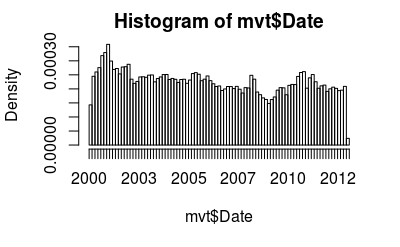

In general , it looks like crime decreases from 2002 - 2012 Also ,it decreased from 2005-2008 And it increased from 2009-2011

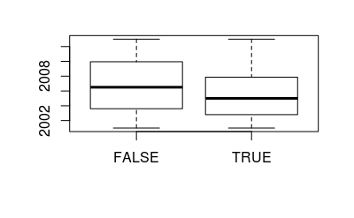

Arrests are made in the first half of the period, since the boxplot for “Arrest = TRUE” is skewed towards the bottom of the plot

```r
table(mvt$Arrest,mvt$Year)
```

```
         2001  2002  2003  2004  2005  2006  2007  2008  2009  2010  2011  2012
  FALSE 18517 16638 14859 15169 14956 14796 13068 13425 11327 14796 15012 13542
  TRUE   2152  2115  1798  1693  1528  1302  1212  1020   840   701   625   550
```

```r
2152/(2152+18517)
```

```
[1] 0.1041173
```

Proportion of motor vehicle thefts for which arrest were made in 2001 = 0.1041173

```r
1212/(13068+1212)
```

```
[1] 0.08487395
```

Proportion of motor vehicle thefts for which arrest were made in 2007 = 0.08487395

```r
550/(550+13542)
```

```
[1] 0.03902924
```

Proportion of motor vehicle thefts for which arrest were made in 2012 = 0.03902924

## Problem - Popular Locations

Analyzing this data could be useful to the Chicago Police Department when deciding where to allocate resources. If they want to increase the number of arrests that are made for motor vehicle thefts, where should they focus their efforts?

```r
sort(table(mvt$LocationDescription))
```

```
    AIRPORT BUILDING NON-TERMINAL - SECURE AREA
                                              1
                 AIRPORT EXTERIOR - SECURE AREA
                                              1
                                ANIMAL HOSPITAL
                                              1
                                APPLIANCE STORE
                                              1
                                      CTA TRAIN
                                              1
                        JAIL / LOCK-UP FACILITY
                                              1
                                      NEWSSTAND
                                              1
                                         BRIDGE
                                              2
              COLLEGE/UNIVERSITY RESIDENCE HALL
                                              2
                              CURRENCY EXCHANGE
                                              2
                                  BOWLING ALLEY
                                              3
                                 CLEANING STORE
                                              3
                          MEDICAL/DENTAL OFFICE
                                              3
                             ABANDONED BUILDING
                                              4
AIRPORT BUILDING NON-TERMINAL - NON-SECURE AREA
                                              4
                                     BARBERSHOP
                                              4
                 LAKEFRONT/WATERFRONT/RIVERBANK
                                              4
                                        LIBRARY
                                              4
                               SAVINGS AND LOAN
                                              4
 AIRPORT TERMINAL UPPER LEVEL - NON-SECURE AREA
                                              5
```

[output cut: 101 more lines]

```
                                           1302
                  RESIDENTIAL YARD (FRONT/BACK)
                                           1536
                         DRIVEWAY - RESIDENTIAL
                                           1675
                                    GAS STATION
                                           2111
                                          ALLEY
                                           2308
                                          OTHER
                                           4573
                 PARKING LOT/GARAGE(NON.RESID.)
                                          14852
                                         STREET
                                         156564
```

Other than ‘Others’ Category , the top 5 locations are STREET, PARKING LOT/GARAGE(NON.RESID.) ,ALLEY ,GAS STATION and DRIVEWAY - RESIDENTIAL

## Subset of top5

```r
Top5 = subset(mvt, LocationDescription=="STREET" | LocationDescription=="PARKING LOT/GARAGE(NON.RESID.)" | LocationDescription=="ALLEY" | LocationDescription=="GAS STATION" | LocationDescription=="DRIVEWAY - RESIDENTIAL")
str(Top5)
```

```
'data.frame':   177510 obs. of  13 variables:
 $ ID                 : int  8951354 8951141 8952223 8951608 8950793 8950760 8951611 8951802 8950706 8951585 ...
 $ Date               : Date, format: "2012-12-31" "2012-12-31" ...
 $ LocationDescription: Factor w/ 78 levels "ABANDONED BUILDING",..: 72 72 72 72 72 72 72 72 72 72 ...
 $ Arrest             : logi  FALSE FALSE FALSE FALSE TRUE FALSE ...
 $ Domestic           : logi  FALSE FALSE FALSE FALSE FALSE FALSE ...
 $ Beat               : int  623 1213 724 211 2521 423 231 1021 1215 1011 ...
 $ District           : int  6 12 7 2 25 4 2 10 12 10 ...
 $ CommunityArea      : int  69 24 67 35 19 48 40 29 24 29 ...
 $ Year               : int  2012 2012 2012 2012 2012 2012 2012 2012 2012 2012 ...
 $ Latitude           : num  41.8 41.9 41.8 41.8 41.9 ...
 $ Longitude          : num  -87.6 -87.7 -87.7 -87.6 -87.8 ...
 $ Month              : chr  "December" "December" "December" "December" ...
 $ Weekday            : chr  "Monday" "Monday" "Monday" "Monday" ...
```

Number of Observations: 177510

```r
Top5$LocationDescription = factor(Top5$LocationDescription)
table(Top5$LocationDescription, Top5$Arrest)
```

```
                                  FALSE   TRUE
  ALLEY                            2059    249
  DRIVEWAY - RESIDENTIAL           1543    132
  GAS STATION                      1672    439
  PARKING LOT/GARAGE(NON.RESID.)  13249   1603
  STREET                         144969  11595
```

Higher Arrest Rate out of Top5 : GAS STATION

```r
table(Top5$LocationDescription,Top5$Weekday)
```

```
                                 Friday Monday Saturday Sunday Thursday Tuesday
  ALLEY                             385    320      341    307      315     323
  DRIVEWAY - RESIDENTIAL            257    255      202    221      263     243
  GAS STATION                       332    280      338    336      282     270
  PARKING LOT/GARAGE(NON.RESID.)   2331   2128     2199   1936     2082    2073
  STREET                          23773  22305    22175  21756    22296   21888

                                 Wednesday
  ALLEY                                317
  DRIVEWAY - RESIDENTIAL               234
  GAS STATION                          273
  PARKING LOT/GARAGE(NON.RESID.)      2103
  STREET                             22371
```

Day of Week with most vehicle thefts at GAS STATION: Saturday(338)

Day of week with fewest vehicle thefts at DRIVEWAY - RESIDENTIAL : Satuday